# Introducción a R

# Análisis de relación

Identificar si la(s) variabl(s) independiente(s) afectan a la variable dependiente.

$$y = \beta_0+ \beta_1 \cdot x +
\epsilon$$

$H_0: $ x no afecta a y, $B_1=0$

$H_a: $ x afecta a y, $B_1 \neq 0$

```r
summary(lm(Sepal.Length ~Sepal.Width, data = iris))
```

```
##
## Call:
## lm(formula = Sepal.Length ~ Sepal.Width, data = iris)
##
## Residuals:
##     Min      1Q  Median      3Q     Max
## -1.5561 -0.6333 -0.1120  0.5579  2.2226
##
## Coefficients:
##             Estimate Std. Error t value Pr(>|t|)
## (Intercept)   6.5262     0.4789   13.63   <2e-16 ***
## Sepal.Width  -0.2234     0.1551   -1.44    0.152
## ---
## Signif. codes:  0 '***' 0.001 '**' 0.01 '*' 0.05 '.' 0.1 ' ' 1
##
## Residual standard error: 0.8251 on 148 degrees of freedom
## Multiple R-squared:  0.01382,    Adjusted R-squared:  0.007159
## F-statistic: 2.074 on 1 and 148 DF,  p-value: 0.1519
```

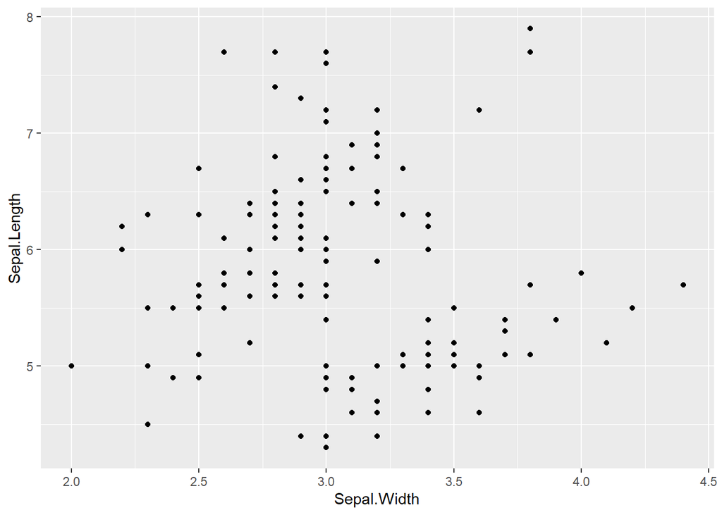

```r
ggplot(iris, aes(x = Sepal.Width, y= Sepal.Length)) +
  geom_point()
```

Con un 95% de confianza el valor de $B_1 = 0$ por lo tanto no se rechaza la hipótesis nula. Se concluye que el ancho del sépalo no tiene relación con el largo del sépalo.

### Ejemplo de alta relación

$H_0: $ petal witdh no afecta a petal length, $B_1=0$

$H_a: $ petal width afecta a petal length, $B_1 \neq 0$

```r
summary(lm(Petal.Length ~Petal.Width, data = iris))
```

```
##
## Call:
## lm(formula = Petal.Length ~ Petal.Width, data = iris)
##
## Residuals:
##      Min       1Q   Median       3Q      Max
## -1.33542 -0.30347 -0.02955  0.25776  1.39453
##
## Coefficients:
##             Estimate Std. Error t value Pr(>|t|)
## (Intercept)  1.08356    0.07297   14.85   <2e-16 ***
## Petal.Width  2.22994    0.05140   43.39   <2e-16 ***
## ---
## Signif. codes:  0 '***' 0.001 '**' 0.01 '*' 0.05 '.' 0.1 ' ' 1
##
## Residual standard error: 0.4782 on 148 degrees of freedom
## Multiple R-squared:  0.9271, Adjusted R-squared:  0.9266
## F-statistic:  1882 on 1 and 148 DF,  p-value: < 2.2e-16
```

Con un 95% de confianza el valor de $B_1 \neq 0$ por lo tanto se rechaza la hipótesis nula; con lo que se concluye que hay efecto del ancho del pétalo en el largo del pétalo.

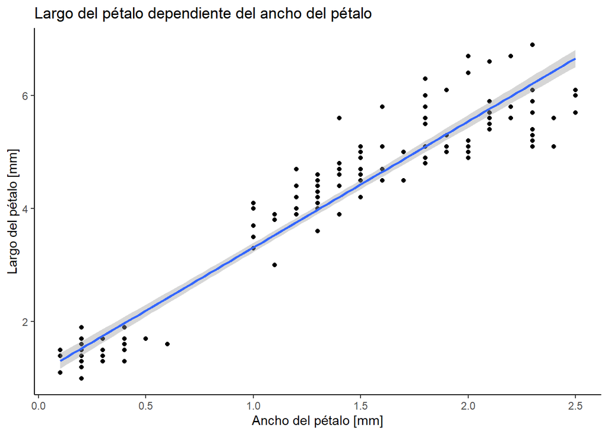

```r
ggplot(iris, aes(x = Petal.Width, y= Petal.Length)) +
  geom_point() +
  geom_smooth(method = "lm") + theme_classic() +
  labs(title = "Largo del pétalo dependiente del ancho del pétalo",
       x = "Ancho del pétalo [mm]",
       y = "Largo del pétalo [mm]")
```